# Pertemuan 1 - Pemulusan

Rani Yasmin Azzahra

```r
library("forecast")
```

```r
library("graphics")
library("TTR")
library("TSA")
```

## Impor Data

```r
library(rio)
data <- import("https://raw.githubusercontent.com/raniysmnz/MPDW/main/Pertemuan%201/Kurs_JPY_PT2123.csv")
```

## Eksplorasi Data

```r
library(dplyr)
glimpse(data)
```

```
## Rows: 489
## Columns: 2
## $ `Time Period` <int> 1, 2, 3, 4, 5, 6, 7, 8, 9, 10, 11, 12, 13, 14, 15, 16, 1…
## $ `Kurs Jual`   <dbl> 13083.57, 13008.99, 13048.83, 13034.11, 13024.67, 12979.…
```

```r
head(data)
```

```
##   Time Period Kurs Jual
## 1           1  13083.57
## 2           2  13008.99
## 3           3  13048.83
## 4           4  13034.11
## 5           5  13024.67
## 6           6  12979.69
```

```r
data.ts <- ts(data$"Kurs Jual")
summary(data.ts)
```

```
##    Min. 1st Qu.  Median    Mean 3rd Qu.    Max.
##   10366   10870   11393   11540   12451   13100
```

Membuat plot data deret waktu

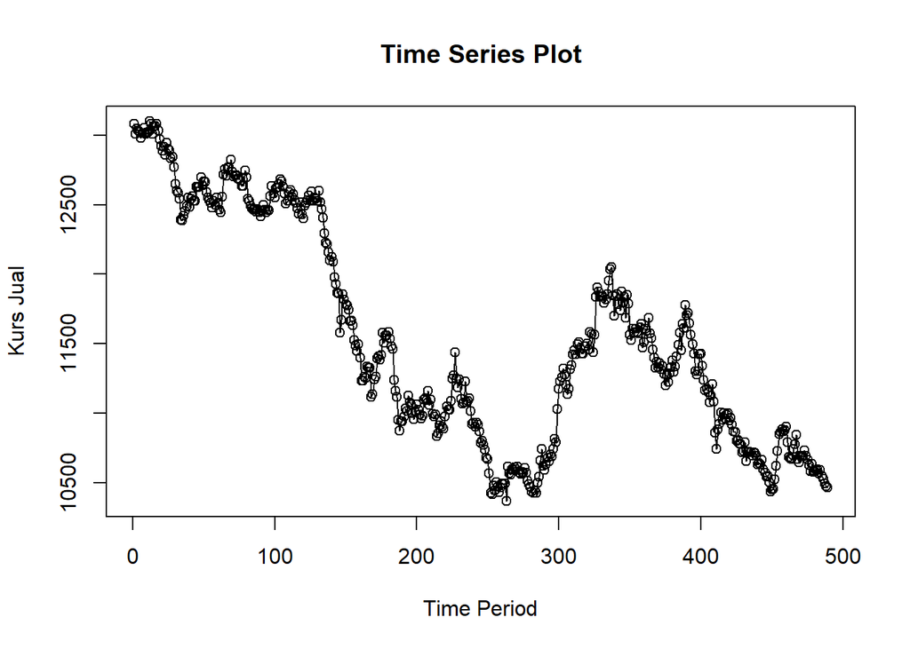

```r
ts.plot(data.ts, xlab="Time Period", ylab="Kurs Jual",
        main = "Time Series Plot")
points(data.ts)
```

```r
ts.plot
```

[output not shown]

Menyimpan plot

```r
#dev.copy(png, "eksplorasi.png")
#dev.off()
```

## Single Moving Average & Double Moving Average

### Pembagian Data

Pembagian data latih dan data uji dilakukan dengan perbandingan 80% data latih dan 20% data uji.

```r
#membagi data latih dan data uji
training_ma <- data[1:391,]
testing_ma <- data[392:489,]
train_ma.ts <- ts(training_ma$"Kurs Jual")
test_ma.ts <- ts(testing_ma$"Kurs Jual")
```

### Eksplorasi Data

Eksplorasi data dilakukan pada keseluruhan data, data latih serta data uji menggunakan plot data deret waktu.

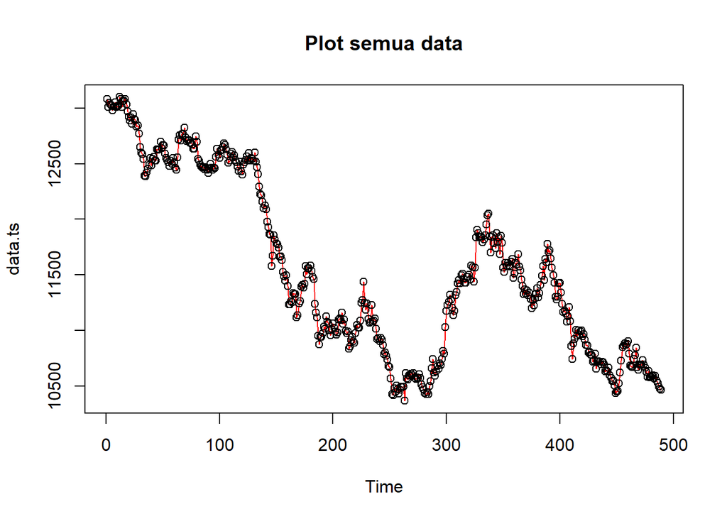

```r
#eksplorasi keseluruhan data
plot(data.ts, col="red",main="Plot semua data")
points(data.ts)
```

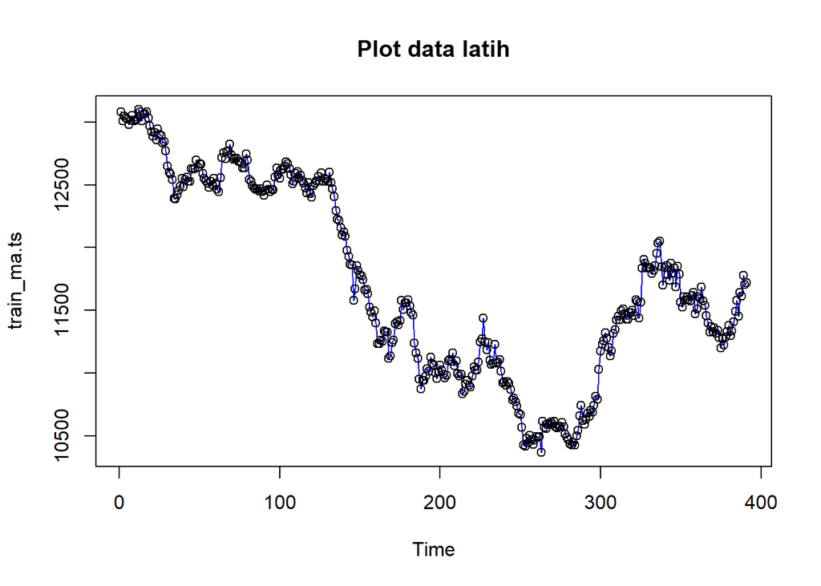

```r
#eksplorasi data latih
plot(train_ma.ts, col="blue",main="Plot data latih")
points(train_ma.ts)
```

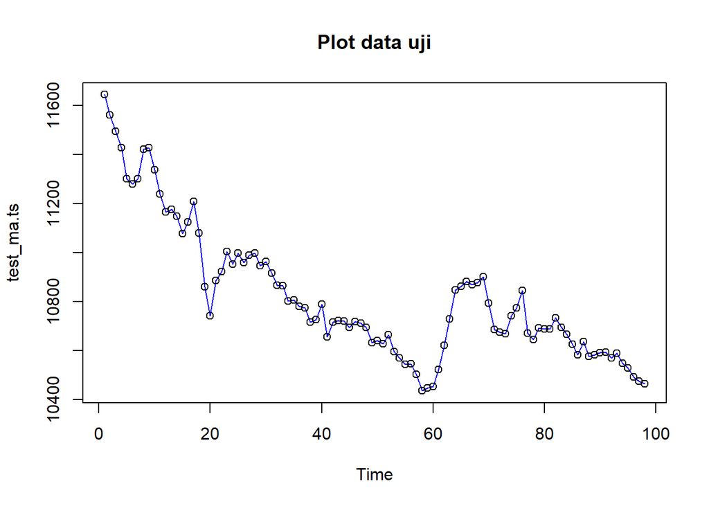

```r
#eksplorasi data uji
plot(test_ma.ts, col="blue",main="Plot data uji")
points(test_ma.ts)
```

```r
training_ma
```

```
##     Time Period Kurs Jual
## 1             1  13083.57
## 2             2  13008.99
## 3             3  13048.83
## 4             4  13034.11
## 5             5  13024.67
## 6             6  12979.69
## 7             7  13015.01
## 8             8  13053.66
## 9             9  13009.49
## 10           10  13015.44
## 11           11  13022.17
## 12           12  13099.74
## 13           13  13083.29
## 14           14  13008.52
```

[output cut: 377 more lines]

```r
testing_ma
```

```
##     Time Period Kurs Jual
## 392         392  11644.68
## 393         393  11561.91
## 394         394  11494.64
## 395         395  11428.70
## 396         396  11301.07
## 397         397  11278.69
## 398         398  11300.29
## 399         399  11422.23
## 400         400  11429.01
## 401         401  11338.67
## 402         402  11238.97
## 403         403  11164.50
## 404         404  11176.57
## 405         405  11149.27
```

[output cut: 84 more lines]

### Single Moving Average (SMA)

Ide dasar dari Single Moving Average (SMA) adalah data suatu periode dipengaruhi oleh data periode sebelumnya. Metode pemulusan ini cocok digunakan untuk pola data stasioner atau konstan. Prinsip dasar metode pemulusan ini adalah data pemulusan pada periode ke-t merupakan rata rata dari m buah data pada periode ke-t hingga periode ke (t-m+1). Data pemulusan pada periode ke-t selanjutnya digunakan sebagai nilai peramalan pada periode ke t+1

Pemulusan menggunakan metode SMA dilakukan dengan fungsi `SMA()`. Dalam hal ini akan dilakukan pemulusan dengan parameter `m=4`.

```r
data.sma<-SMA(train_ma.ts, n=4)
data.sma
```

```
## Time Series:
## Start = 1
## End = 391
## Frequency = 1
##   [1]       NA       NA       NA 13043.88 13029.15 13021.83 13013.37 13018.26
##   [9] 13014.46 13023.40 13025.19 13036.71 13055.16 13053.43 13063.04 13055.23
##  [17] 13054.47 13060.31 13038.20 13001.30 12952.64 12923.76 12895.08 12901.57
##  [25] 12906.05 12900.36 12894.77 12868.98 12836.20 12775.39 12717.11 12652.56
##  [33] 12595.38 12530.30 12476.17 12434.86 12412.96 12437.50 12478.83 12494.84
##  [41] 12516.80 12534.87 12529.19 12539.67 12560.58 12576.20 12602.06 12645.15
##  [49] 12647.81 12659.51 12667.08 12640.34 12619.04 12584.17 12546.37 12518.37
##  [57] 12511.88 12503.91 12514.42 12523.25 12507.71 12493.78 12494.61 12545.58
##  [65] 12617.85 12684.44 12737.54 12750.93 12768.78 12776.18 12759.42 12744.83
##  [73] 12717.07 12704.21 12700.58 12690.21 12670.52 12657.63 12673.16 12678.88
##  [81] 12655.44 12628.86 12565.03 12509.06 12489.22 12474.30 12463.78 12462.89
```

[output cut: 38 more lines]

Data pemulusan pada periode ke-t selanjutnya digunakan sebagai nilai peramalan pada periode ke t+1 sehingga hasil peramalan 1 periode kedepan adalah sebagai berikut.

```r
data.ramal<-c(NA,data.sma)
data.ramal #forecast 1 periode ke depan
```

```
##   [1]       NA       NA       NA       NA 13043.88 13029.15 13021.83 13013.37
##   [9] 13018.26 13014.46 13023.40 13025.19 13036.71 13055.16 13053.43 13063.04
##  [17] 13055.23 13054.47 13060.31 13038.20 13001.30 12952.64 12923.76 12895.08
##  [25] 12901.57 12906.05 12900.36 12894.77 12868.98 12836.20 12775.39 12717.11
##  [33] 12652.56 12595.38 12530.30 12476.17 12434.86 12412.96 12437.50 12478.83
##  [41] 12494.84 12516.80 12534.87 12529.19 12539.67 12560.58 12576.20 12602.06
##  [49] 12645.15 12647.81 12659.51 12667.08 12640.34 12619.04 12584.17 12546.37
##  [57] 12518.37 12511.88 12503.91 12514.42 12523.25 12507.71 12493.78 12494.61
##  [65] 12545.58 12617.85 12684.44 12737.54 12750.93 12768.78 12776.18 12759.42
##  [73] 12744.83 12717.07 12704.21 12700.58 12690.21 12670.52 12657.63 12673.16
##  [81] 12678.88 12655.44 12628.86 12565.03 12509.06 12489.22 12474.30 12463.78
##  [89] 12462.89 12457.92 12444.26 12444.66 12451.96 12457.79 12465.45 12467.80
##  [97] 12458.70 12483.07 12530.78 12560.83 12583.80 12598.13 12595.36 12611.96
## [105] 12644.19 12655.95 12656.95 12639.94 12597.07 12562.23 12552.52 12558.78
## [113] 12569.92 12582.06 12567.69 12543.94 12523.95 12488.46 12484.46 12463.77
```

[output cut: 34 more lines]

```r
data.gab<-cbind(aktual=c(train_ma.ts,rep(NA,24)),pemulusan=c(data.sma,rep(NA,24)),ramalan=c(data.ramal,rep(data.ramal[length(data.ramal)],23)))
data.gab #forecast 24 periode ke depan
```

```
##          aktual pemulusan  ramalan
##   [1,] 13083.57        NA       NA
##   [2,] 13008.99        NA       NA
##   [3,] 13048.83        NA       NA
##   [4,] 13034.11  13043.88       NA
##   [5,] 13024.67  13029.15 13043.88
##   [6,] 12979.69  13021.83 13029.15
##   [7,] 13015.01  13013.37 13021.83
##   [8,] 13053.66  13018.26 13013.37
##   [9,] 13009.49  13014.46 13018.26
##  [10,] 13015.44  13023.40 13014.46
##  [11,] 13022.17  13025.19 13023.40
##  [12,] 13099.74  13036.71 13025.19
##  [13,] 13083.29  13055.16 13036.71
##  [14,] 13008.52  13053.43 13055.16
```

[output cut: 401 more lines]

Adapun plot data deret waktu dari hasil peramalan yang dilakukan adalah sebagai berikut.

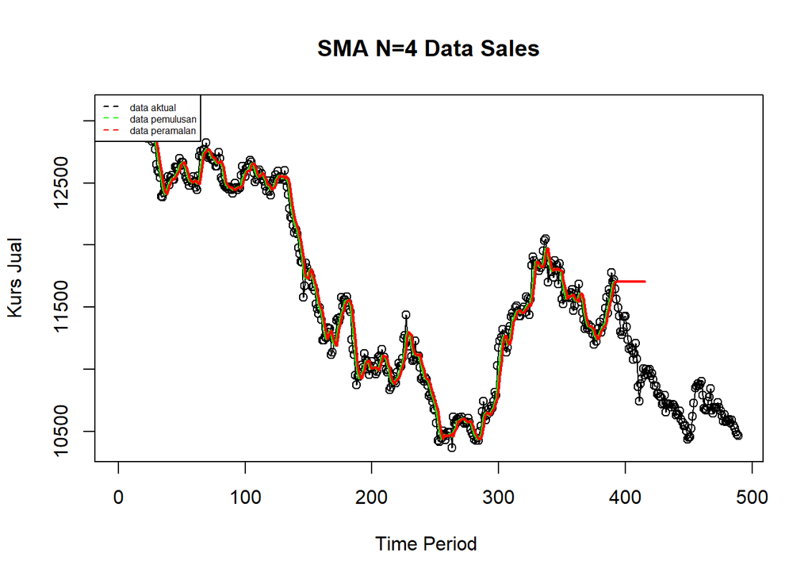

```r
ts.plot(data.ts, xlab="Time Period ", ylab="Kurs Jual", main= "SMA N=4 Data Sales")
points(data.ts)
lines(data.gab[,2],col="green",lwd=2)
lines(data.gab[,3],col="red",lwd=2)
legend("topleft",c("data aktual","data pemulusan","data peramalan"), lty=8, col=c("black","green","red"), cex=0.5)
```

Selanjutnya perhitungan akurasi dilakukan dengan ukuran akurasi *Sum Squares Error* (SSE), *Mean Square Error* (MSE) dan *Mean Absolute Percentage Error* (MAPE). Perhitungan akurasi dilakukan baik pada data latih maupun pada data uji.

```r
#Menghitung nilai keakuratan data latih
error_train.sma = train_ma.ts-data.ramal[1:length(train_ma.ts)]
SSE_train.sma = sum(error_train.sma[5:length(train_ma.ts)]^2)
MSE_train.sma = mean(error_train.sma[5:length(train_ma.ts)]^2)
MAPE_train.sma = mean(abs((error_train.sma[5:length(train_ma.ts)]/train_ma.ts[5:length(train_ma.ts)])*100))

akurasi_train.sma <- matrix(c(SSE_train.sma, MSE_train.sma, MAPE_train.sma))
row.names(akurasi_train.sma)<- c("SSE", "MSE", "MAPE")
colnames(akurasi_train.sma) <- c("Akurasi m = 4")
akurasi_train.sma
```

```
##      Akurasi m = 4
## SSE   3.945391e+06
## MSE   1.019481e+04
## MAPE  6.601011e-01
```

Dalam hal ini nilai MAPE data latih pada metode pemulusan SMA kurang dari 2%, nilai ini dapat dikategorikan sebagai nilai akurasi yang sangat baik. Selanjutnya dilakukan perhitungan nilai MAPE data uji pada metde pemulusan SMA.

```r
#Menghitung nilai keakuratan data uji
error_test.sma = test_ma.ts-data.gab[392:415,3]
```

```r
SSE_test.sma = sum(error_test.sma^2)
MSE_test.sma = mean(error_test.sma^2)
MAPE_test.sma = mean(abs((error_test.sma/test_ma.ts*100)))

akurasi_test.sma <- matrix(c(SSE_test.sma, MSE_test.sma, MAPE_test.sma))
row.names(akurasi_test.sma)<- c("SSE", "MSE", "MAPE")
colnames(akurasi_test.sma) <- c("Akurasi m = 4")
akurasi_test.sma
```

```
##      Akurasi m = 4
## SSE   8.336989e+07
## MSE   8.507132e+05
## MAPE  8.208902e+00
```

### Double Moving Average (DMA)

Metode pemulusan Double Moving Average (DMA) pada dasarnya mirip dengan SMA. Namun demikian, metode ini lebih cocok digunakan untuk pola data trend. Proses pemulusan dengan rata rata dalam metode ini dilakukan sebanyak 2 kali.

```r
dma <- SMA(data.sma, n = 4)
At <- 2*data.sma - dma
Bt <- 2/(4-1)*(data.sma - dma)
data.dma<- At+Bt
data.ramal2<- c(NA, data.dma)

t = 1:24
f = c()

for (i in t) {
  f[i] = At[length(At)] + Bt[length(Bt)]*(i)
}

data.gab2 <- cbind(aktual = c(train_ma.ts,rep(NA,24)), pemulusan1 = c(data.sma,rep(NA,24)),pemulusan2 = c(data.dma, rep(NA,24)),At = c(At, rep(NA,24)), Bt = c(Bt,rep(NA,24)),ramalan = c(data.ramal2, f[-1]))
data.gab2
```

```
##          aktual pemulusan1 pemulusan2       At            Bt  ramalan
##   [1,] 13083.57         NA         NA       NA            NA       NA
##   [2,] 13008.99         NA         NA       NA            NA       NA
##   [3,] 13048.83         NA         NA       NA            NA       NA
##   [4,] 13034.11   13043.88         NA       NA            NA       NA
##   [5,] 13024.67   13029.15         NA       NA            NA       NA
##   [6,] 12979.69   13021.83         NA       NA            NA       NA
##   [7,] 13015.01   13013.37   12990.56 12999.68   -9.12333333       NA
##   [8,] 13053.66   13018.26   13014.27 13015.86   -1.59541667 12990.56
##   [9,] 13009.49   13014.46   13010.27 13011.95   -1.67750000 13014.27
##  [10,] 13015.44   13023.40   13033.45 13029.43    4.01833333 13010.27
##  [11,] 13022.17   13025.19   13033.29 13030.05    3.24166667 13033.45
##  [12,] 13099.74   13036.71   13056.33 13048.48    7.84625000 13033.29
##  [13,] 13083.29   13055.16   13088.57 13075.20   13.36333333 13056.33
##  [14,] 13008.52   13053.43   13071.44 13064.24    7.20500000 13088.57
```

[output cut: 401 more lines]

Hasil pemulusan menggunakan metode DMA divisualisasikan sebagai berikut

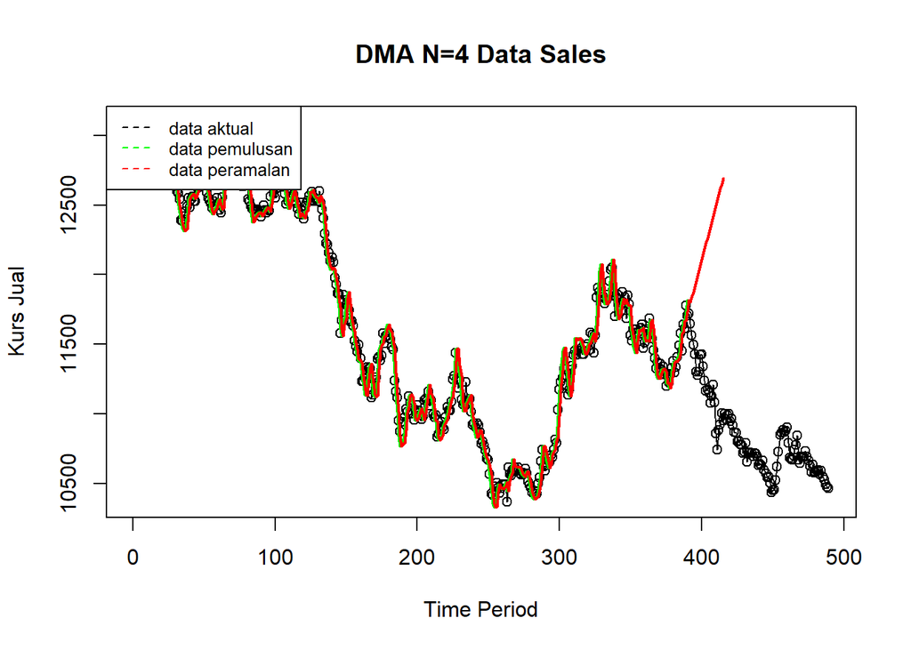

```r
ts.plot(data.ts, xlab="Time Period", ylab="Kurs Jual", main= "DMA N=4 Data Sales")
points(data.ts)
lines(data.gab2[,3],col="green",lwd=2)
lines(data.gab2[,6],col="red",lwd=2)
legend("topleft",c("data aktual","data pemulusan","data peramalan"), lty=8, col=c("black","green","red"), cex=0.8)
```

Selanjutnya perhitungan akurasi dilakukan baik pada data latih maupun data uji. Perhitungan akurasi dilakukan dengan ukuran akurasi SSE, MSE dan MAPE.

```r
#Menghitung nilai keakuratan data latih
error_train.dma = train_ma.ts-data.ramal2[1:length(train_ma.ts)]
SSE_train.dma = sum(error_train.dma[8:length(train_ma.ts)]^2)
MSE_train.dma = mean(error_train.dma[8:length(train_ma.ts)]^2)
MAPE_train.dma = mean(abs((error_train.dma[8:length(train_ma.ts)]/train_ma.ts[8:length(train_ma.ts)])*100))

akurasi_train.dma <- matrix(c(SSE_train.dma, MSE_train.dma, MAPE_train.dma))
row.names(akurasi_train.dma)<- c("SSE", "MSE", "MAPE")
colnames(akurasi_train.dma) <- c("Akurasi m = 4")
akurasi_train.dma
```

```
##      Akurasi m = 4
## SSE   3.451544e+06
## MSE   8.988395e+03
## MAPE  6.335257e-01
```

Perhitungan akurasi pada data latih menggunakan nilai MAPE menghasilkan nilai MAPE yang kurang dari 10% sehingga dikategorikan sangat baik. Selanjutnya, perhitungan nilai akurasi dilakukan pada data uji.

```r
#Menghitung nilai keakuratan data uji
error_test.dma = test_ma.ts-data.gab2[391:415,6]
```

```r
SSE_test.dma = sum(error_test.dma^2)
MSE_test.dma = mean(error_test.dma^2)
MAPE_test.dma = mean(abs((error_test.dma/test_ma.ts*100)))

akurasi_test.dma <- matrix(c(SSE_test.dma, MSE_test.dma, MAPE_test.dma))
row.names(akurasi_test.dma)<- c("SSE", "MSE", "MAPE")
colnames(akurasi_test.dma) <- c("Akurasi m = 4")
akurasi_test.dma
```

```
##      Akurasi m = 4
## SSE   2.094107e+08
## MSE   2.136844e+06
## MAPE  1.299575e+01
```

### DES

Metode pemulusan *Double Exponential Smoothing* (DES) digunakan untuk data yang memiliki pola tren. Metode DES adalah metode semacam SES, hanya saja dilakukan dua kali, yaitu pertama untuk tahapan ‘level’ dan kedua untuk tahapan ‘tren’. Pemulusan menggunakan metode ini akan menghasilkan peramalan tidak konstan untuk periode berikutnya.

Pemulusan dengan metode DES kali ini akan menggunakan fungsi `HoltWinters()` . Jika sebelumnya nilai argumen `beta` dibuat `FALSE` , kali ini argumen tersebut akan diinisialisasi bersamaan dengan nilai `alpha` .

```r
#membagi training dan testing
training<-data[1:391,]
testing<-data[392:489,]
train.ts <- ts(training$"Kurs Jual")
test.ts <- ts(testing$"Kurs Jual")
```

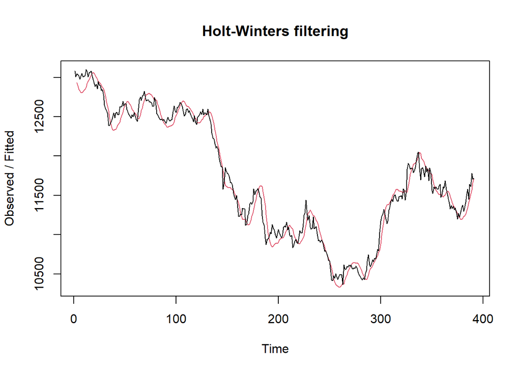

```r
#Lamda=0.2 dan gamma=0.2
des.1<- HoltWinters(train.ts, gamma = FALSE, beta = 0.2, alpha = 0.2)
plot(des.1)
```

```r
#ramalan
ramalandes1<- forecast(des.1, h=98)
ramalandes1
```

```
##     Point Forecast    Lo 80    Hi 80    Lo 95    Hi 95
## 392       11757.97 11593.31 11922.62 11506.15 12009.78
## 393       11803.92 11634.59 11973.25 11544.95 12062.89
## 394       11849.87 11674.38 12025.37 11581.48 12118.27
## 395       11895.82 11712.59 12079.06 11615.59 12176.05
## 396       11941.78 11749.19 12134.36 11647.25 12236.30
## 397       11987.73 11784.19 12191.26 11676.45 12299.00
## 398       12033.68 11817.64 12249.72 11703.27 12364.09
## 399       12079.63 11849.59 12309.68 11727.81 12431.45
## 400       12125.58 11880.12 12371.04 11750.18 12500.98
## 401       12171.53 11909.33 12433.74 11770.52 12572.55
## 402       12217.49 11937.28 12497.69 11788.95 12646.02
## 403       12263.44 11964.08 12562.80 11805.60 12721.27
## 404       12309.39 11989.77 12629.01 11820.58 12798.20
## 405       12355.34 12014.45 12696.24 11833.99 12876.69
```

[output cut: 84 more lines]

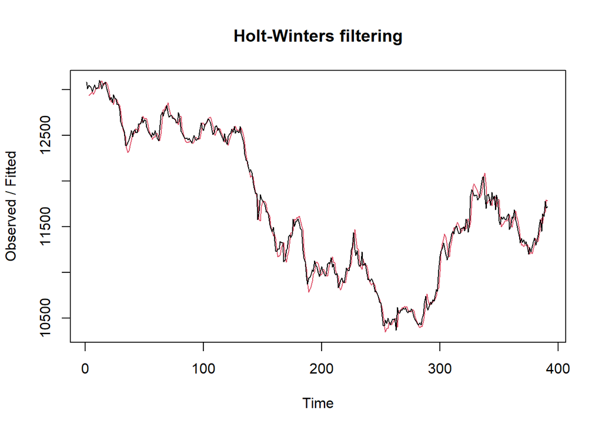

```r
#Lamda=0.6 dan gamma=0.3
des.2<- HoltWinters(train.ts, gamma = FALSE, beta = 0.3, alpha = 0.6)
plot(des.2)
```

```r
#ramalan
ramalandes2<- forecast(des.2, h=98)
ramalandes2
```

```
##     Point Forecast     Lo 80    Hi 80       Lo 95    Hi 95
## 392       11776.43 11672.320 11880.54 11617.20836 11935.65
## 393       11808.54 11676.506 11940.57 11606.61179 12010.47
## 394       11840.65 11675.055 12006.25 11587.39451 12093.91
## 395       11872.76 11669.027 12076.50 11561.17650 12184.35
## 396       11904.87 11659.122 12150.62 11529.03022 12280.71
## 397       11936.98 11645.813 12228.15 11491.67688 12382.29
## 398       11969.09 11629.431 12308.76 11449.62393 12488.56
## 399       12001.20 11610.220 12392.19 11403.24627 12599.16
## 400       12033.31 11588.372 12478.26 11352.83323 12713.80
## 401       12065.43 11564.036 12566.82 11298.61649 12832.23
## 402       12097.54 11537.338 12657.73 11240.78710 12954.29
## 403       12129.65 11508.384 12750.91 11179.50649 13079.79
## 404       12161.76 11477.263 12846.25 11114.91370 13208.60
## 405       12193.87 11444.057 12943.68 11047.13038 13340.61
```

[output cut: 84 more lines]

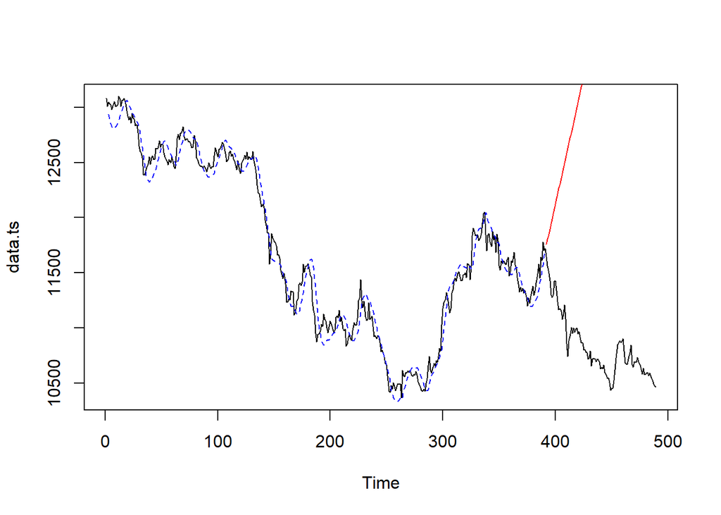

```r
#Visually evaluate the prediction
plot(data.ts)
lines(des.1$fitted[,1], lty=2, col="blue")
lines(ramalandes1$mean, col="red")
```

Untuk mendapatkan nilai parameter optimum dari DES, argumen `alpha` dan `beta` dapat dibuat `NULL` seperti berikut.

```r
#Lamda dan gamma optimum
des.opt<- HoltWinters(train.ts, gamma = FALSE)
des.opt
```

```
## Holt-Winters exponential smoothing with trend and without seasonal component.
##
## Call:
## HoltWinters(x = train.ts, gamma = FALSE)
##
## Smoothing parameters:
##  alpha: 0.9984039
##  beta : 0.0513992
##  gamma: FALSE
##
## Coefficients:
##          [,1]
## a 11717.91612
## b    11.55383
```

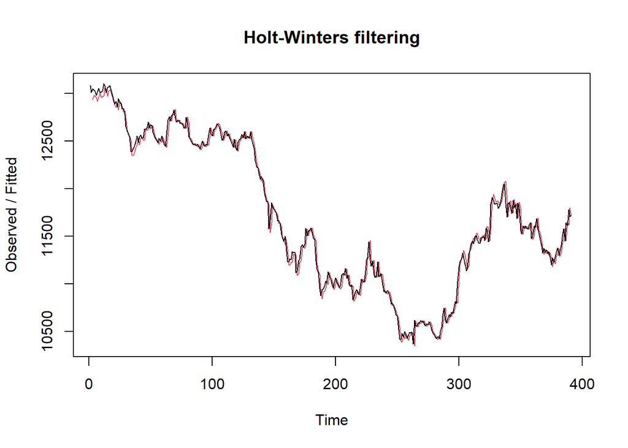

```r
plot(des.opt)
```

```r
#ramalan
ramalandesopt<- forecast(des.opt, h=98)
ramalandesopt
```

```
##     Point Forecast     Lo 80    Hi 80     Lo 95    Hi 95
## 392       11729.47 11633.808 11825.13 11583.167 11875.77
## 393       11741.02 11602.333 11879.71 11528.914 11953.13
## 394       11752.58 11578.425 11926.73 11486.234 12018.92
## 395       11764.13 11558.021 11970.24 11448.913 12079.35
## 396       11775.69 11539.592 12011.78 11414.612 12136.76
## 397       11787.24 11522.374 12052.10 11382.163 12192.31
## 398       11798.79 11505.929 12091.66 11350.896 12246.69
## 399       11810.35 11489.977 12130.72 11320.384 12300.31
## 400       11821.90 11474.333 12169.47 11290.342 12353.46
## 401       11833.45 11458.866 12208.04 11260.570 12406.34
## 402       11845.01 11443.478 12246.54 11230.921 12459.10
## 403       11856.56 11428.100 12285.02 11201.286 12511.84
## 404       11868.12 11412.677 12323.56 11171.582 12564.65
## 405       11879.67 11397.166 12362.17 11141.743 12617.60
```

[output cut: 84 more lines]

Selanjutnya akan dilakukan perhitungan akurasi pada data latih maupun data uji dengan ukuran akurasi SSE, MSE dan MAPE.

#### Akurasi Data Latih

```r
#Akurasi Data Training
ssedes.train1<-des.1$SSE
msedes.train1<-ssedes.train1/length(train.ts)
sisaandes1<-ramalandes1$residuals
head(sisaandes1)
```

```
## Time Series:
## Start = 1
## End = 6
## Frequency = 1
## [1]       NA       NA 114.4200 146.8192 172.1458 149.9812
```

```r
mapedes.train1 <- sum(abs(sisaandes1[3:length(train.ts)]/train.ts[3:length(train.ts)])
                      *100)/length(train.ts)

akurasides.1 <- matrix(c(ssedes.train1,msedes.train1,mapedes.train1))
row.names(akurasides.1)<- c("SSE", "MSE", "MAPE")
colnames(akurasides.1) <- c("Akurasi lamda=0.2 dan gamma=0.2")
akurasides.1
```

```
##      Akurasi lamda=0.2 dan gamma=0.2
## SSE                     6.428129e+06
## MSE                     1.644023e+04
## MAPE                    8.849476e-01
```

```r
ssedes.train2<-des.2$SSE
msedes.train2<-ssedes.train2/length(train.ts)
sisaandes2<-ramalandes2$residuals
head(sisaandes2)
```

```
## Time Series:
## Start = 1
## End = 6
## Frequency = 1
## [1]         NA         NA 114.420000  85.032400  63.251528   7.613904
```

```r
mapedes.train2 <- sum(abs(sisaandes2[3:length(train.ts)]/train.ts[3:length(train.ts)])
                      *100)/length(train.ts)

akurasides.2 <- matrix(c(ssedes.train2,msedes.train2,mapedes.train2))
row.names(akurasides.2)<- c("SSE", "MSE", "MAPE")
colnames(akurasides.2) <- c("Akurasi lamda=0.6 dan gamma=0.3")
akurasides.2
```

```
##      Akurasi lamda=0.6 dan gamma=0.3
## SSE                     2.561460e+06
## MSE                     6.551048e+03
## MAPE                    5.268737e-01
```

Hasil akurasi dari data latih didapatkan skenario 2 dengan lamda=0.6 dan gamma=0.3 memiliki hasil yang lebih baik. Namun untuk kedua skenario dapat dikategorikan peramalan sangat baik berdasarkan nilai MAPE-nya.

#### Akurasi Data Uji

```r
#Akurasi Data Testing
selisihdes1<-ramalandes1$mean-testing$"Kurs Jual"
selisihdes1
```

```
## Time Series:
## Start = 392
## End = 489
## Frequency = 1
##  [1]  113.2879  242.0098  355.2317  467.1236  640.7055  709.0374  733.3893
##  [8]  657.4012  696.5731  832.8650  978.5168 1098.9387 1132.8206 1206.0725
## [15] 1324.0244 1322.6063 1284.8582 1459.3701 1724.7020 1890.7539 1792.0958
## [22] 1801.1177 1765.8695 1863.2014 1862.8333 1947.8552 1963.6971 2001.1490
## [29] 2098.9909 2127.0728 2220.5847 2316.1966 2365.3485 2472.1904 2514.1522
## [36] 2585.9141 2638.4060 2743.3879 2776.9298 2760.8217 2941.3136 2926.1855
## [43] 2966.9374 3015.0093 3085.4412 3108.5931 3161.1649 3222.9268 3333.1487
## [50] 3369.3906 3427.8925 3438.2344 3551.4663 3623.3482 3696.6101 3739.8420
## [57] 3828.9739 3941.9958 3975.9676 4015.9795 3993.5614 3940.5733 3879.0752
## [64] 3806.7471 3837.3690 3863.7609 3922.6828 3958.9747 3982.1066 4136.4185
## [71] 4289.5903 4345.4422 4398.7741 4371.4960 4384.5579 4359.0998 4581.0217
## [78] 4651.9836 4650.9255 4699.5774 4746.4393 4746.9612 4832.0930 4906.1249
## [85] 4992.0468 5082.1887 5074.7406 5179.9525 5219.4444 5256.6463 5300.4682
## [92] 5371.0201 5396.3720 5483.5938 5548.3757 5631.6076 5694.5295 5752.6814
```

```r
SSEtestingdes1<-sum(selisihdes1^2)
MSEtestingdes1<-SSEtestingdes1/length(testing$"Kurs Jual")
MAPEtestingdes1<-sum(abs(selisihdes1/testing$"Kurs Jual")*100)/length(testing$"Kurs Jual")

selisihdes2<-ramalandes2$mean-testing$"Kurs Jual"
selisihdes2
```

```
## Time Series:
## Start = 392
## End = 489
## Frequency = 1
##  [1]  131.7490  246.6297  346.0105  444.0612  603.8019  658.2927  668.8034
##  [8]  578.9741  604.3048  726.7556  858.5663  965.1470  985.1878 1044.5985
## [15] 1148.7092 1133.4499 1081.8607 1242.5314 1494.0221 1646.2328 1533.7336
## [22] 1528.9143 1479.8250 1563.3158 1549.1065 1620.2872 1622.2879 1645.8987
## [29] 1729.8994 1744.1401 1823.8109 1905.5816 1940.8923 2033.8930 2062.0138
## [36] 2119.9345 2158.5852 2249.7260 2269.4267 2239.4774 2406.1281 2377.1589
## [43] 2404.0696 2438.3003 2494.8910 2504.2018 2542.9325 2590.8532 2687.2340
## [50] 2709.6347 2754.2954 2750.7961 2850.1869 2908.2276 2967.6483 2997.0391
## [57] 3072.3298 3171.5105 3191.6412 3217.8120 3181.5527 3114.7234 3039.3842
## [64] 2953.2149 2969.9956 2982.5463 3027.6271 3050.0778 3059.3685 3199.8392
## [71] 3339.1700 3381.1807 3420.6714 3379.5522 3378.7729 3339.4736 3547.5543
## [78] 3604.6751 3589.7758 3624.5865 3657.6073 3644.2880 3715.5787 3775.7694
## [85] 3847.8502 3924.1509 3902.8616 3994.2324 4019.8831 4043.2438 4073.2245
## [92] 4129.9353 4141.4460 4214.8267 4265.7674 4335.1582 4384.2389 4428.5496
```

```r
SSEtestingdes2<-sum(selisihdes2^2)
MSEtestingdes2<-SSEtestingdes2/length(testing$"Kurs Jual")
MAPEtestingdes2<-sum(abs(selisihdes2/testing$"Kurs Jual")*100)/length(testing$"Kurs Jual")

selisihdesopt<-ramalandesopt$mean-testing$"Kurs Jual"
selisihdesopt
```

```
## Time Series:
## Start = 392
## End = 489
## Frequency = 1
##  [1]   84.78995  179.11378  257.93762  335.43145  474.61529  508.54912
##  [7]  498.50295  388.11679  392.89062  494.78446  606.03829  692.06212
## [13]  691.54596  730.39979  813.95363  778.13746  705.99129  846.10513
## [19] 1077.03896 1208.69280 1075.63663 1050.26046  980.61430 1043.54813
## [25] 1008.78197 1059.40580 1040.84963 1043.90347 1107.34730 1101.03114
## [31] 1160.14497 1221.35880 1236.11264 1308.55647 1316.12031 1353.48414
## [37] 1371.57797 1442.16181 1441.30564 1390.79948 1536.89331 1487.36714
## [43] 1493.72098 1507.39481 1543.42864 1532.18248 1550.35631 1577.72015
## [49] 1653.54398 1655.38781 1679.49165 1655.43548 1734.26932 1771.75315
## [55] 1810.61698 1819.45082 1874.18465 1952.80849 1952.38232 1957.99615
## [61] 1901.17999 1813.79382 1717.89766 1611.17149 1607.39532 1599.38916
## [67] 1623.91299 1625.80683 1614.54066 1734.45449 1853.22833 1874.68216
## [73] 1893.61600 1831.93983 1810.60366 1750.74750 1938.27133 1974.83517
## [79] 1939.37900 1953.63283 1966.09667 1932.22050 1982.95434 2022.58817
## [85] 2074.11200 2129.85584 2088.00967 2158.82351 2163.91734 2166.72117
## [91] 2176.14501 2212.29884 2203.25268 2256.07651 2286.46034 2335.29418
## [97] 2363.81801 2387.57185
```

```r
SSEtestingdesopt<-sum(selisihdesopt^2)
MSEtestingdesopt<-SSEtestingdesopt/length(testing$"Kurs Jual")
MAPEtestingdesopt<-sum(abs(selisihdesopt/testing$"Kurs Jual")*100)/length(testing$"Kurs Jual")

akurasitestingdes <-
  matrix(c(SSEtestingdes1,MSEtestingdes1,MAPEtestingdes1,SSEtestingdes2,MSEtestingdes2,
           MAPEtestingdes2,SSEtestingdesopt,MSEtestingdesopt,MAPEtestingdesopt),
         nrow=3,ncol=3)
row.names(akurasitestingdes)<- c("SSE", "MSE", "MAPE")
colnames(akurasitestingdes) <- c("des ske1","des ske2","des opt")
akurasitestingdes
```

```
##          des ske1     des ske2      des opt
## SSE  1.210234e+09 7.454939e+08 2.429407e+08
## MSE  1.234933e+07 7.607081e+06 2.478986e+06
## MAPE 2.956053e+01 2.345245e+01 1.369304e+01
```